# R Notebook

```r
data(mtcars)
head(mtcars)
```

|  | mpg | cyl | disp | hp | drat | wt | qsec | vs | am | gear | carb |
| --- | --- | --- | --- | --- | --- | --- | --- | --- | --- | --- | --- |
| Mazda RX4 | 21.0 | 6 | 160 | 110 | 3.90 | 2.620 | 16.46 | 0 | 1 | 4 | 4 |
| Mazda RX4 Wag | 21.0 | 6 | 160 | 110 | 3.90 | 2.875 | 17.02 | 0 | 1 | 4 | 4 |
| Datsun 710 | 22.8 | 4 | 108 | 93 | 3.85 | 2.320 | 18.61 | 1 | 1 | 4 | 1 |
| Hornet 4 Drive | 21.4 | 6 | 258 | 110 | 3.08 | 3.215 | 19.44 | 1 | 0 | 3 | 1 |
| Hornet Sportabout | 18.7 | 8 | 360 | 175 | 3.15 | 3.440 | 17.02 | 0 | 0 | 3 | 2 |
| Valiant | 18.1 | 6 | 225 | 105 | 2.76 | 3.460 | 20.22 | 1 | 0 | 3 | 1 |

```r
mod1 <- glm(vs ~ mpg, data=mtcars, family=binomial)
summary(mod1)
```

```
##
## Call:
## glm(formula = vs ~ mpg, family = binomial, data = mtcars)
##
## Coefficients:
##             Estimate Std. Error z value Pr(>|z|)
## (Intercept)  -8.8331     3.1623  -2.793  0.00522 **
## mpg           0.4304     0.1584   2.717  0.00659 **
## ---
## Signif. codes:  0 '***' 0.001 '**' 0.01 '*' 0.05 '.' 0.1 ' ' 1
##
## (Dispersion parameter for binomial family taken to be 1)
##
##     Null deviance: 43.860  on 31  degrees of freedom
## Residual deviance: 25.533  on 30  degrees of freedom
## AIC: 29.533
##
## Number of Fisher Scoring iterations: 6
```

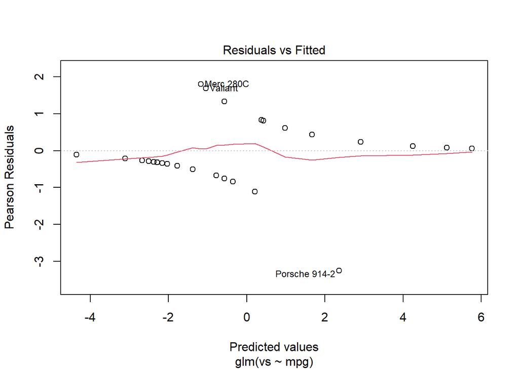

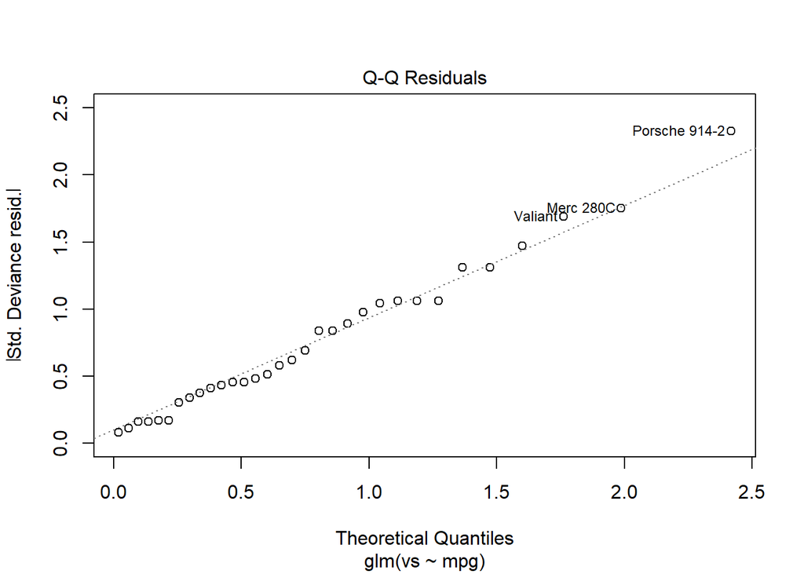

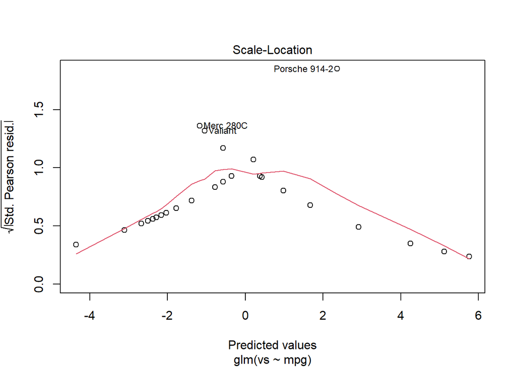

```r
plot(mod1)
```

[figure not shown]

```r
library(ggplot2)
```

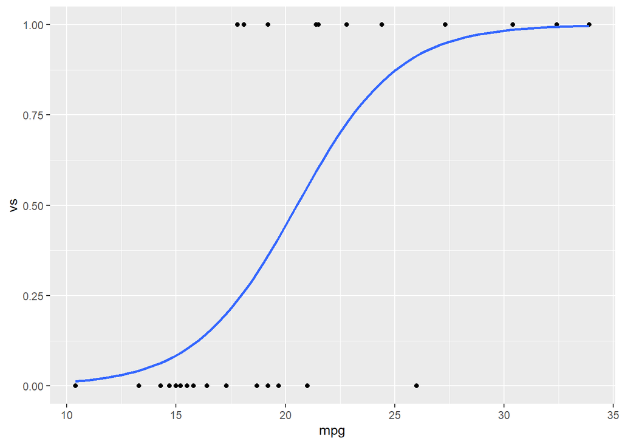

```r
ggplot(mtcars, aes(x=mpg, y=vs)) +
  geom_point() +
  stat_smooth(method="glm", method.args=list(family="binomial"), se=FALSE)
```

```r
mod2 <- glm(vs ~ am, data=mtcars, family=binomial)
summary(mod2)
```

```
##
## Call:
## glm(formula = vs ~ am, family = binomial, data = mtcars)
##
## Coefficients:
##             Estimate Std. Error z value Pr(>|z|)
## (Intercept)  -0.5390     0.4756  -1.133    0.257
## am            0.6931     0.7319   0.947    0.344
##
## (Dispersion parameter for binomial family taken to be 1)
##
##     Null deviance: 43.860  on 31  degrees of freedom
## Residual deviance: 42.953  on 30  degrees of freedom
## AIC: 46.953
##
## Number of Fisher Scoring iterations: 4
```

```r
mod3 <- glm(vs ~ mpg + am, data=mtcars, family=binomial)
summary(mod3)
```

```
##
## Call:
## glm(formula = vs ~ mpg + am, family = binomial, data = mtcars)
##
## Coefficients:
##             Estimate Std. Error z value Pr(>|z|)
## (Intercept) -12.7051     4.6252  -2.747  0.00602 **
## mpg           0.6809     0.2524   2.698  0.00697 **
## am           -3.0073     1.5995  -1.880  0.06009 .
## ---
## Signif. codes:  0 '***' 0.001 '**' 0.01 '*' 0.05 '.' 0.1 ' ' 1
##
## (Dispersion parameter for binomial family taken to be 1)
##
##     Null deviance: 43.860  on 31  degrees of freedom
## Residual deviance: 20.646  on 29  degrees of freedom
## AIC: 26.646
##
## Number of Fisher Scoring iterations: 6
```

```r
mod4 <- glm(vs ~ mpg + am, data=mtcars, family=binomial(link="probit"))
summary(mod4)
```

```
##
## Call:
## glm(formula = vs ~ mpg + am, family = binomial(link = "probit"),
##     data = mtcars)
##
## Coefficients:
##             Estimate Std. Error z value Pr(>|z|)
## (Intercept)  -7.4735     2.4437  -3.058  0.00223 **
## mpg           0.3998     0.1335   2.994  0.00275 **
## am           -1.8390     0.9126  -2.015  0.04389 *
## ---
## Signif. codes:  0 '***' 0.001 '**' 0.01 '*' 0.05 '.' 0.1 ' ' 1
##
## (Dispersion parameter for binomial family taken to be 1)
##
##     Null deviance: 43.860  on 31  degrees of freedom
## Residual deviance: 20.347  on 29  degrees of freedom
## AIC: 26.347
##
## Number of Fisher Scoring iterations: 7
```

```r
mod5 <- lm(vs ~ mpg + am, data=mtcars)
summary(mod5)
```

```
##
## Call:
## lm(formula = vs ~ mpg + am, data = mtcars)
##
## Residuals:
##      Min       1Q   Median       3Q      Max
## -0.65671 -0.24013 -0.03289  0.22379  0.68162
##
## Coefficients:
##             Estimate Std. Error t value Pr(>|t|)
## (Intercept) -0.89278    0.24409  -3.658   0.0010 **
## mpg          0.07355    0.01340   5.490  6.5e-06 ***
## am          -0.36283    0.16181  -2.242   0.0328 *
## ---
## Signif. codes:  0 '***' 0.001 '**' 0.01 '*' 0.05 '.' 0.1 ' ' 1
##
## Residual standard error: 0.3597 on 29 degrees of freedom
## Multiple R-squared:  0.5236, Adjusted R-squared:  0.4907
## F-statistic: 15.93 on 2 and 29 DF,  p-value: 2.144e-05
```

## 1. Logistic model with mpg only:

The positive mpg coefficient (0.4304) indicates that higher mpg (better fuel efficiency) increases the probability of having a V-shaped engine (vs=1). The significant p-value for mpg (0.00659) suggests a significant effect.

## 2. Logistic model with am only:

The positive am coefficient (0.6931) but non-significant p-value (0.344) indicates that automatic transmission does not seem to have a significant effect on vs in this simple model.

## 3. Logistic model with mpg and am:

mpg has a positive and significant effect (coeff=0.6809, p=0.00697) am has a negative but marginally significant effect (coeff=-3.0073, p=0.06009) Together, mpg and am appear to have important effects on vs.

## 4. Probit model with mpg and am:

The coefficients differ from the logistic model, but the effect directions and significance are similar. The probit model assumes a normal distribution rather than logistic.

## 5. Linear model with mpg and am:

A linear model is not appropriate for a binary outcome variable like vs. The coefficients are not directly interpretable in terms of probabilities.

The logistic model with mpg and am appears most appropriate. An increase in mpg increases the probability of having a V-shaped engine, while automatic transmission seems to decrease this probability, although marginally significant. The probit model yields similar conclusions.